# R Notebook

R is a free software environment for statistical computing and graphics.

I personally believe that R provides user friendly coding, especially for visual learners.

It is also one of the best programs available for creating highly customizable, publication quality graphics.

Like Python, R can perform mathematic functions for us

```r
5 + 5
```

```
## [1] 10
```

```r
5 * 5
```

```
## [1] 25
```

```r
5 / 5
```

```
## [1] 1
```

When using R studio, you can see variable values on the right hand side (below global environment)

```r
x = 5
```

You can alter variables with mathematic functions by including that variable in what you are setting it equal to (compared to python where we can use += )

```r
x = x + 2
x = x * 3
```

Observing data types in R (Double is essentially float in python). Note that even whole numbers default to double.

```r
typeof(x)
```

```
## [1] "double"
```

You can convert data types using the different functions: as.numeric(), as.double(), as.integer(), as.character()

```r
x = 5.5
x = as.integer(x)
typeof(x)
```

```
## [1] "integer"
```

Note the L in the right hand side after the numeric value indicates the number is now in integer format

Concatenating characters in R requires a function such as paste(), rather than just using + (unlike python strings)

```r
y = "Hello"
z = "world!"
yz = paste(y, z, sep=" ")
```

You can also utilize loops in r like you can in python. However, the syntax is different.

The example below is a while loop designed to print every even number between and including 0 to 20

The conditional states to enter the loop if x is less than or equal to 20. Since 0 satisfies this, it enters the loop, prints the iterable x, then adds 2 to x. Since 2 is less than or equal to 20, it reenters the loops. This process continues until x = 22.

```r
x = 0
while (x <= 20) {
  print(x)
  x = x + 2
}
```

```
## [1] 0
## [1] 2
## [1] 4
## [1] 6
## [1] 8
## [1] 10
## [1] 12
## [1] 14
## [1] 16
## [1] 18
## [1] 20
```

The example below creates a numeric set, x, and then counts the number of even numbers in that set.

This for loop does this by setting a counter to zero. It then loops through all the values in the set x.

The loop states that if the value of the current element can be divided by 2 with a remainder of 0, then to add 1 to the count. This process continues until you loop through all the elements in set x. Finally, we print the count.

```r
x <- c(2, 5, 3, 9, 8, 11, 6, 22, 11, 2, 4, 3, 2, 6, 8)
count = 0
for (val in x) {
  if (val %% 2 == 0)
    count = count + 1
}
print(count)
```

```
## [1] 9
```

Loading in a custom data frame. Use the following syntax

```r
df <-
  data.frame(
    Name = c("Skyler", "Rachael", "Keith", "Adam", "Tina"),
    Age = c(29, 25, 30, 11, 40)
  )
print (df)
```

```
##      Name Age
## 1  Skyler  29
## 2 Rachael  25
## 3   Keith  30
## 4    Adam  11
## 5    Tina  40
```

The install commands are commented out because they only need to be ran once on your machine. Remove the to run the line.

```r
#install.packages('ggplot2', dep = TRUE)
#install.packages('ggthemes', dep = TRUE)
```

The library will need to be loaded every time you reopen the file. We will use ggplot2 later

```r
library(ggplot2)
```

We will now set our working directory. This is my favorite way to do it because it can be saved for later, but you can also go to the the top of the screen and use session -> set working directory -> choose working directory, or control shift H in windows. YOU MUST ALTER THE PATH TO WEHRE YOU HAVE YOUR FILES SAVED. BELOW IS AN EXAMPLE THAT WILL ONLY WORK FOR ME. setwd(“C:/Users/Skyler/desktop”)

This line loads in your .csv file. You can save the file as a .csv file using Excel (save as).

This file is an example of how data from the VA database might look. This is only sample data and all patient identifiers are fake.

```r
Data <- read.csv("data/DummyData_COVID_Antipsych3.csv")
```

Subsetting data - Subsetting your data can be extremely powerful in R. You must first understand your scientific inquiries before you begin to do this. We work to isolate the cohorts as required for our studies and then we can perform statistical analyses.

The following lines can be used to subset the data. The first line subsets the file to only include veterans. We do this by telling it to include Veterans or Veteran-Employees. The | symbol means “or”. The second and third lines subset the veterans further depending on whether or not they are on a 1st gen antipsychotic. != means not equal to. NOte that a patient can be on 1st gen antipsychotics as either an inpatient or an outpatient, so both must be included. The next two lines split the entire file based on gender (note that this is subsetting the original file, not just the veterans. You can change this to include only the veterans # by replacing “Data” with “Vet”). The next three lines subset the original file by age range (below 18. 18-65, and 65+)

```
|   "or"  means true if any conditional is true

&   "&"   means true if all conditionals are true
```

```r
Vet <- subset(Data, Data$PatientCategory=="Veteran" | Data$PatientCategory=="Veteran-Employee")

VetOn1st <- subset(Vet, Vet$InPt.1st.Typical.Antipsychotic !="NULL" |                 Vet$OutPt.1st.Gen.Typical.Antipsychotic !="NULL")

VetNotOn1st <- subset(Vet, Vet$InPt.1st.Typical.Antipsychotic=="NULL" & Vet$OutPt.1st.Gen.Typical.Antipsychotic=="NULL")

Males <- subset(Data, Data$Sex=="M")
Females <- subset(Data, Data$Sex=="F")
Children <- subset(Data, Data$AgeAtIndex<18)
Adults <- subset(Data, Data$AgeAtIndex>17 & Data$AgeAtIndex<65)
Seniors <- subset(Data, Data$AgeAtIndex>64)
```

Recombining subsets - Use rbind()

```r
Males_or_Females <- rbind(Males,Females)
```

The following line shows you how you can create subsets of specific tables using only specified columns

```r
ColumnsSeniors <- subset(Seniors, select = c(PatientICN, InPt.1st.Typical.Antipsychotic, AgeAtIndex))
```

The next two lines can quickly show you the first or last six lines (respectively), plus the header of a particular table. I did this to easily check that the previous code worked. This is also important because clicking into the data using the global environments to the right won’t display all the data if there are too many columns or rows.

```r
head(ColumnsSeniors)
```

|  | PatientICN | InPt.1st.Typical.Antipsychotic | AgeAtIndex |
| --- | --- | --- | --- |
| 1 | 1 | NULL | 65 |
| 2 | 2 | NULL | 78 |
| 3 | 3 | NULL | 101 |
| 4 | 4 | HALOPERIDOL | 89 |
| 5 | 5 | NULL | 70 |
| 9 | 9 | NULL | 78 |

```r
tail(ColumnsSeniors)
```

|  | PatientICN | InPt.1st.Typical.Antipsychotic | AgeAtIndex |
| --- | --- | --- | --- |
| 22 | 22 | NULL | 85 |
| 23 | 23 | NULL | 73 |
| 25 | 25 | NULL | 87 |
| 26 | 26 | NULL | 86 |
| 27 | 27 | NULL | 74 |
| 28 | 28 | NULL | 71 |

Data summary statistics

Gathering summary statistics for categorical data

```r
length(Seniors$Race)
```

```
## [1] 17
```

```r
table(Seniors$Race)
```

```
##
## American Indian or Alaska Native                            Asian
##                                2                                2
##        Black or African American                             NULL
##                                2                                1
##                          Unknown                            White
##                                2                                8
```

```r
prop.table(table(Seniors$Race))
```

```
##
## American Indian or Alaska Native                            Asian
##                       0.11764706                       0.11764706
##        Black or African American                             NULL
##                       0.11764706                       0.05882353
##                          Unknown                            White
##                       0.11764706                       0.47058824
```

The next few lines show you how you can begin to analyze the numerical data in a particular column.

The histogram function has additional parameters that could customize it further See documentation for hist() online or use the final line of code in this section.

```r
mean(Seniors$AgeAtIndex)
```

```
## [1] 78.52941
```

```r
range(Seniors$AgeAtIndex)
```

```
## [1]  65 101
```

```r
sd(Seniors$AgeAtIndex)
```

```
## [1] 10.78261
```

Remove the # below to install the package Rmisc install.packages(“Rmisc”)

```r
library(Rmisc)
CI(Seniors$AgeAtIndex, .95)
```

```
##    upper     mean    lower
## 84.07332 78.52941 72.98550
```

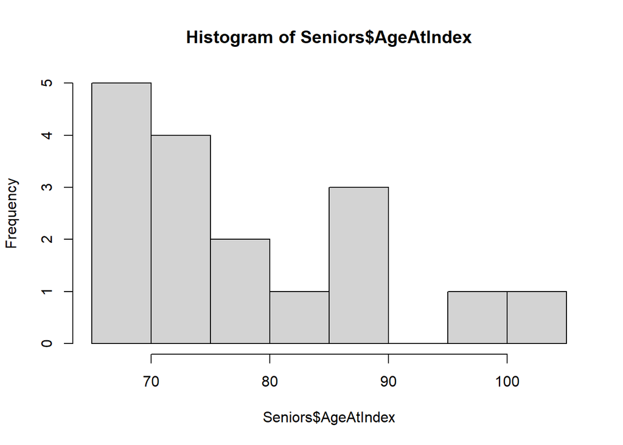

```r
hist(Seniors$AgeAtIndex)
```

```r
help(hist)
```

```
## starting httpd help server ...
```

```
##  done
```

You can also use different packages to create highly customizable, publication quality figures. ggplot2 is excellent for this and you can use google to get codes that you can modify based on your needs. The code below gives box plots showing the ages of the veterans (I used the veteran only subset) based on race (x-axis) and gender (key). Use Google to search for ggplot chart types to find one that can display what you intend to look at. The documentation will have additional options for modifications.

```r
library(ggthemes)
```

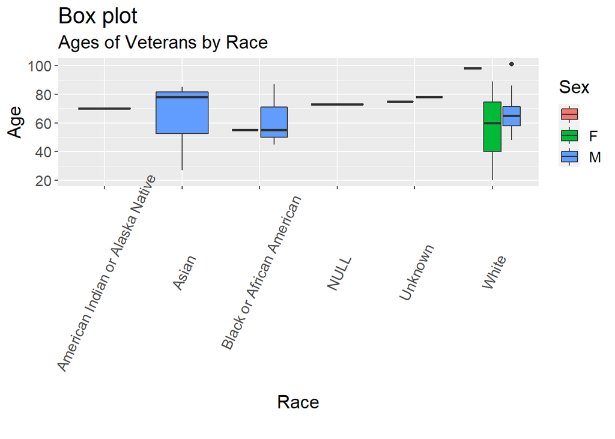

```r
g <- ggplot(Vet, aes(Race, AgeAtIndex))
g + geom_boxplot(aes(fill=Sex)) +
  theme(text = element_text(size=15), axis.text.x = element_text(angle=65, vjust=0.6)) +
  labs(title="Box plot",
       subtitle="Ages of Veterans by Race",
       caption="",
       x="Race",
       y="Age")
```

Note that there is a problem with our dataset in that we have two categories for an Unknown race, “Unknown” and “NULL”. The code below can turn all the “NULL” values in that column into “Unknown”. We can then rerun the code for the graph.

```r
Vet$Race[Vet$Race == "NULL"] <- "Unknown"
```

Note: You can also use the code below to replace all the “NULL” values in the entire file into “Unknown”

```r
Vet[Vet == "NULL"] <- "Unknown"
```

We also have an individual who did not list their sex. We can subset again to remove this and then rerun the code one final time.

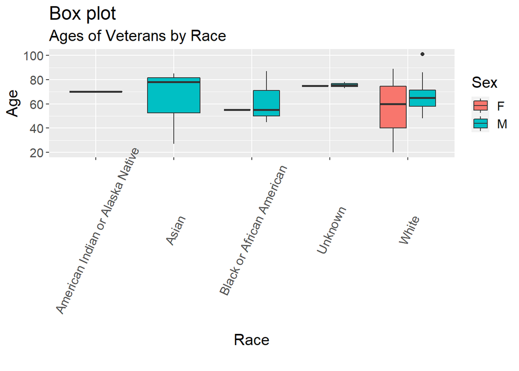

```r
vet2 <- subset(Vet, Sex == "M" | Sex == "F")
g <- ggplot(vet2, aes(Race, AgeAtIndex))
g + geom_boxplot(aes(fill=Sex)) +
  theme(text = element_text(size=15), axis.text.x = element_text(angle=65, vjust=0.6)) +
  labs(title="Box plot",
       subtitle="Ages of Veterans by Race",
       caption="",
       x="Race",
       y="Age")
```

These are the sorts of things that you will have to do if your dataset is messy.

Modifying data with ifelse function: The following syntax can be used. The arguments are a conditional, a value if true, then a value if false.

```r
Vet$FirstPositive <- ifelse(Vet$FirstPositive=="NULL",0,1)
```

Adding a new column: You can add a new column to the data. These values can be set or they can be based off of calculations utilizing other columns. For example, the following creates a column that multiplies the patients age by their patient identifier (a more realistic/useful example will follow this)

```r
Vet$newinfo <- (Vet$AgeAtIndex*Vet$PatientSID)
```

The following line will compare two specified columns with dates in them and add a new column, “date_diff”, that shows the amount of time between those two columns. The format parameter shows that the dates are in month/day/year format. If you have columns in a different format, the code will need to be changed.

```r
Vet$date_diff <- as.Date(as.character(Vet$IndexICUAdmitDate), format="%m/%d/%Y") - as.Date(as.character(Vet$IndexDate), format="%m/%d/%Y")
```

We can then use the head function to make sure that all the functions we used above worked properly.

```r
head(Vet)
```

|  | PatientICN | PatientSID | PatientCategory | Race | Sex | AgeAtIndex | IndexCaseSta6a | Sta6a | IndexCaseSta3n | State | PatientStatus | CaseDefinition | EverPositive | IndexDate | No..Days.to.Nearest.Admit.Date | FirstPositive | RecentPositive | FirstNegative | RecentNegative | CaseDateTime | CD.DateTime | CD.DateDischarge | AdmitDateTime | DischargeDateTime | AdmitSourceType | POS.COVID.Test | POS.Lab.Result | POS.Specimen.Taken.Date | POS.Complete.Date | … |
| --- | --- | --- | --- | --- | --- | --- | --- | --- | --- | --- | --- | --- | --- | --- | --- | --- | --- | --- | --- | --- | --- | --- | --- | --- | --- | --- | --- | --- | --- | --- |
| 1 | 1 | 100 | Veteran | White | M | 65 | A | B | C | NEW YORK | Active | VA Presumptive Positive | 0 | 5/30/2020 | 1 | 1 | Unknown | 5/30/2020 21:30 | 9/28/2020 11:45 | 1/20/2021 21:20 | 1/21/2021 0:49 | 1/23/2021 8:18 | 5/31/2020 0:30 | 6/1/2020 17:10 | Outpatient | Unknown | Unknown | Unknown | Unknown | … |
| 2 | 2 | 99 | Veteran | Unknown | M | 78 | A | B | C | FLORIDA | Other | VA Respiratory Illness Seen | 1 | 4/7/2020 | Unknown | 1 | 4/7/2020 12:00 | Unknown | Unknown | 4/7/2020 12:00 | Unknown | Unknown | Unknown | Unknown | Unknown | COVID-19 (CPL) | Unknown | 4/3/2020 10:39 | 4/5/2020 10:25 | … |
| 3 | 3 | 98 | Veteran | White | M | 101 | A | B | C | TEXAS | Death | VA Negative | 0 | 7/18/2018 | 1 | 1 | Unknown | 9/18/2020 9:42 | 9/18/2020 9:42 | 9/18/2020 9:42 | 9/19/2020 0:43 | 9/20/2020 19:24 | 9/19/2020 0:43 | 9/20/2020 19:24 | Direct | Unknown | Unknown | Unknown | Unknown | … |
| 4 | 4 | 97 | Veteran | White | F | 89 | A | B | C | ARKANSAS | Negative | VA Negative | 0 | 10/13/2020 | 0 | 1 | Unknown | 10/13/2020 14:09 | 10/13/2020 14:09 | 10/13/2020 14:09 | 10/14/2020 0:57 | 10/19/2020 7:00 | 10/14/2020 0:57 | 10/15/2020 7:06 | Outpatient | Unknown | Unknown | Unknown | Unknown | … |
| 5 | 5 | 96 | Veteran | American Indian or Alaska Native | M | 70 | A | B | C | ARIZONA | Other | VA Respiratory Illness Seen | 0 | 3/2/2020 | 0 | 1 | Unknown | 3/2/2020 13:40 | 3/3/2020 13:40 | 3/4/2020 13:40 | Unknown | Unknown | 3/2/2020 18:13 | 3/5/2020 12:13 | Outpatient | Unknown | Unknown | Unknown | Unknown | … |
| 6 | 6 | 95 | Veteran | White | M | 54 | A | B | C | GEORGIA | Pending | VA Pending | 0 | 4/1/2020 | 52 | 1 | Unknown | 4/1/2020 14:25 | 8/12/2020 15:28 | 8/12/2020 15:28 | 5/23/2020 1:32 | 5/23/2020 13:25 | 5/23/2020 1:32 | 5/23/2020 13:25 | NursingHomeOrDom | Unknown | Unknown | Unknown | Unknown | … |

Finally, this line can create a .csv file from one of your subsets. The file will save to your working directory unless you specify otherwise.

```r
write.csv(Vet, file = "./data/Vet.csv")
```

Now let’s start looking at Linear Regression

```r
prostate <- read.csv("./data/prostate.csv")
```

Since we do not have any hyperparamters to tune, let’s split the data into training and test sets!

```r
train <- subset(prostate, train=="TRUE")[,1:9]
test <- subset(prostate, train=="FALSE")[,1:9]
```

```r
nrow(train)
```

```
## [1] 67
```

```r
nrow(test)
```

```
## [1] 30
```

## visualize the data

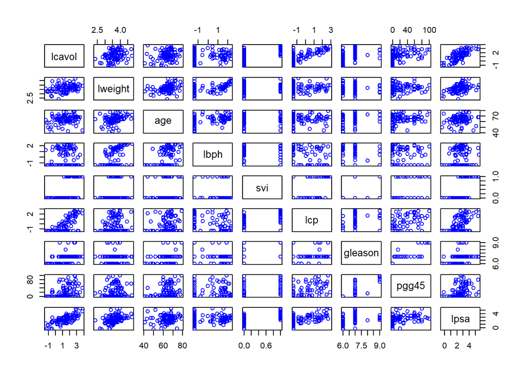

```r
pairs(prostate[,1:9], col="blue")
```

Assessing data types

```r
str(prostate)
```

```
## 'data.frame':    97 obs. of  10 variables:
##  $ lcavol : num  -0.58 -0.994 -0.511 -1.204 0.751 ...
##  $ lweight: num  2.77 3.32 2.69 3.28 3.43 ...
##  $ age    : int  50 58 74 58 62 50 64 58 47 63 ...
##  $ lbph   : num  -1.39 -1.39 -1.39 -1.39 -1.39 ...
##  $ svi    : int  0 0 0 0 0 0 0 0 0 0 ...
##  $ lcp    : num  -1.39 -1.39 -1.39 -1.39 -1.39 ...
##  $ gleason: int  6 6 7 6 6 6 6 6 6 6 ...
##  $ pgg45  : int  0 0 20 0 0 0 0 0 0 0 ...
##  $ lpsa   : num  -0.431 -0.163 -0.163 -0.163 0.372 ...
##  $ train  : logi  TRUE TRUE TRUE TRUE TRUE TRUE ...
```

Let’s fit our model using the training data

```r
fit1 <- lm(lpsa ~ ., data = train)
summary(fit1)
```

```
##
## Call:
## lm(formula = lpsa ~ ., data = train)
##
## Residuals:
##      Min       1Q   Median       3Q      Max
## -1.64870 -0.34147 -0.05424  0.44941  1.48675
##
## Coefficients:
##              Estimate Std. Error t value Pr(>|t|)
## (Intercept)  0.429170   1.553588   0.276  0.78334
## lcavol       0.576543   0.107438   5.366 1.47e-06 ***
## lweight      0.614020   0.223216   2.751  0.00792 **
## age         -0.019001   0.013612  -1.396  0.16806
## lbph         0.144848   0.070457   2.056  0.04431 *
## svi          0.737209   0.298555   2.469  0.01651 *
## lcp         -0.206324   0.110516  -1.867  0.06697 .
## gleason     -0.029503   0.201136  -0.147  0.88389
## pgg45        0.009465   0.005447   1.738  0.08755 .
## ---
## Signif. codes:  0 '***' 0.001 '**' 0.01 '*' 0.05 '.' 0.1 ' ' 1
##
## Residual standard error: 0.7123 on 58 degrees of freedom
## Multiple R-squared:  0.6944, Adjusted R-squared:  0.6522
## F-statistic: 16.47 on 8 and 58 DF,  p-value: 2.042e-12
```

lcavol and lweight are highly significant

Compute 95% confidence interval

```r
confint(fit1,level=0.95)
```

```
##                    2.5 %      97.5 %
## (Intercept) -2.680674329 3.539014595
## lcavol       0.361482785 0.791603586
## lweight      0.167204780 1.060835229
## age         -0.046248270 0.008246226
## lbph         0.003813690 0.285882474
## svi          0.139585747 1.334831542
## lcp         -0.427546584 0.014898130
## gleason     -0.432120510 0.373114741
## pgg45       -0.001437213 0.020367537
```

How well does our model do when we generalize it to an independent test set?

Prediction - Make predictions of your column 9, AKA actual level of prostate-specific antigen (lpsa) using the model.

```r
prediction1 <- predict(fit1, newdata = test[,1:8])
predict(fit1, newdata = test[,1:8], interval = "confidence", level=0.95)
```

```
##         fit       lwr      upr
## 7  1.969038 1.6785306 2.259546
## 9  1.169956 0.6363138 1.703598
## 10 1.261179 0.9259166 1.596442
## 15 1.883759 1.4364585 2.331060
## 22 2.544319 2.0023996 3.086238
## 25 1.932754 1.5695879 2.295920
## 26 2.042336 1.5907971 2.493874
## 28 1.830916 1.3867040 2.275129
## 32 1.991159 1.6462489 2.336069
## 34 1.323471 0.9697893 1.677152
## 36 2.938431 2.4846387 3.392224
## 42 2.203144 1.7635614 2.642727
## 44 2.166421 1.5894574 2.743385
## 48 2.794562 2.4697310 3.119394
```

[output cut: 16 more lines]

```r
mean((prediction1-test[,9])^2)
```

```
## [1] 0.521274
```